# Practical Machine Learning Project

Anastasia Illarionova

September 17, 2020

## 1. Weight Lifting Exercise Dataset. Exploratory analysis

This project is dedicated for the exploration of Weight Lifting Exercise Dataset. The main goal is to predict the manner in which participants did the exercise based on available metrics. The variable that has to be predicted, classe, includes 5 classes: A, B, C, D and E. We checked two non-linear model fittings for a prediction: Descision Tree and Random Forest, implemented in a caret R package (v6.0-86). Final model was applied on a testing test with 20 observations. The original datasets was uploaded without the index and the datetime (fourth) columns which were not considered as predictor variables.

```r
suppressPackageStartupMessages(library(readr))
suppressPackageStartupMessages(library(ggfortify))
suppressPackageStartupMessages(library(caret))
suppressPackageStartupMessages(library(randomForest))
suppressPackageStartupMessages(library(ggpubr))
```

```r
pml_testing = read_csv("pml-testing.csv", col_types = cols(X1 = col_skip(), cvtd_timestamp = col_skip()), na = c("NA", "#DIV/0!", ""))
pml_training = read_csv("pml-training.csv", col_types = cols(X1 = col_skip(), cvtd_timestamp = col_skip()), na = c("NA", "#DIV/0!", ""))

# Convert classe and user_name variables into a factor type
pml_training$classe = as.factor(pml_training$classe)
pml_training$user_name = as.factor(pml_training$user_name)
```

Cleaning data step was performed, during which columns with more then 90% of missing values (NA) were removed.

```r
training = pml_training[, which(colSums(is.na(pml_training))/nrow(pml_training) <= 0.9)]
testing = pml_testing[, colnames(training)[1:57]]
```

We conducted a PCA and plotted the first two PCs to access variability and clustering pattern of data (Figure 1).

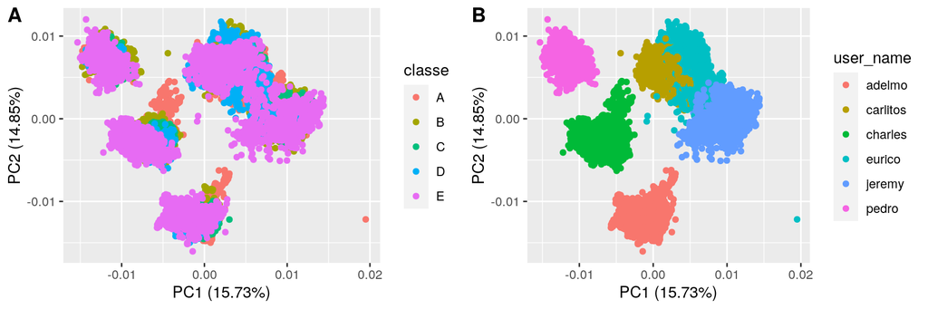

```r
pca_res <- prcomp(training[, -c(1,4, 58)], na.omit=TRUE, scale. = TRUE)

cl = autoplot(pca_res, data = training, colour = "classe")
u = autoplot(pca_res, data = training, colour = "user_name")

ggarrange(cl, u, labels = c("A", "B"), ncol = 2, nrow = 1)
```

Figure1. PCA plot of a training dataset. Observations are colored by A) classe and B) user name.

As can be seen from the Figure 1 the cases are clustered by users. Observations comming from different performance classes form subclusters within the main groups. The first and the second PCs explains ~30% of overall variability.

## 2. Class prediction

We started to fit the data with non-linear models for the class prediction. First, we separate data into training and cross-validation sets.

```r
set.seed(10)
train_index = createDataPartition(training$classe, p = 3/4)[[1]]
tdf = training[train_index, ]

# Create a non-overlapping cross-validation dataset
vdf = training[-train_index, ]
```

Next, we applied a Descision Tree algorithm. During the preprocess step the input predictor variables were centered and scaled.

```r
modelFit_dt = train(classe ~ .,data = tdf, preProcess = c("center", "scale"), method = 'rpart')
DT_output_cross_v = predict(modelFit_dt, vdf)
confusionMatrix(vdf$classe, DT_output_cross_v)
```

```
## Confusion Matrix and Statistics
##
##           Reference
## Prediction    A    B    C    D    E
##          A 1269   21  102    0    3
##          B  386  336  227    0    0
##          C  405   23  427    0    0
##          D  337  150  317    0    0
##          E  126  130  238    0  407
##
## Overall Statistics
##
##                Accuracy : 0.4973
##                  95% CI : (0.4833, 0.5114)
##     No Information Rate : 0.5145
##     P-Value [Acc > NIR] : 0.9921
##
##                   Kappa : 0.3435
##
##  Mcnemar's Test P-Value : NA
##
## Statistics by Class:
##
##                      Class: A Class: B Class: C Class: D Class: E
## Sensitivity            0.5030  0.50909  0.32571       NA  0.99268
## Specificity            0.9471  0.85556  0.88088   0.8361  0.89008
## Pos Pred Value         0.9097  0.35406  0.49942       NA  0.45172
## Neg Pred Value         0.6426  0.91808  0.78167       NA  0.99925
## Prevalence             0.5145  0.13458  0.26733   0.0000  0.08361
## Detection Rate         0.2588  0.06852  0.08707   0.0000  0.08299
## Detection Prevalence   0.2845  0.19352  0.17435   0.1639  0.18373
## Balanced Accuracy      0.7250  0.68233  0.60329       NA  0.94138
```

As can be seen from the confusion matrix, the overall accuracy is low and the No Information Rate is high which means that the model does not do any usefull predictions and may be skewed to the class with a majority of instances (A, 30%).

Thus, we run a Random Forest algorithm on the same data set. As before the input predictor variables were centered and scaled.

```r
modelFit_rf = train(classe ~ .,data = tdf, preProcess = c("center", "scale"), method = "rf")
RF_output_cross_v = predict(modelFit_rf, vdf)
confusionMatrix(vdf$classe, RF_output_cross_v)
```

```
## Confusion Matrix and Statistics
##
##           Reference
## Prediction    A    B    C    D    E
##          A 1395    0    0    0    0
##          B    0  949    0    0    0
##          C    0    2  853    0    0
##          D    0    0    1  803    0
##          E    0    0    0    0  901
##
## Overall Statistics
##
##                Accuracy : 0.9994
##                  95% CI : (0.9982, 0.9999)
##     No Information Rate : 0.2845
##     P-Value [Acc > NIR] : < 2.2e-16
##
##                   Kappa : 0.9992
##
##  Mcnemar's Test P-Value : NA
##
## Statistics by Class:
##
##                      Class: A Class: B Class: C Class: D Class: E
## Sensitivity            1.0000   0.9979   0.9988   1.0000   1.0000
## Specificity            1.0000   1.0000   0.9995   0.9998   1.0000
## Pos Pred Value         1.0000   1.0000   0.9977   0.9988   1.0000
## Neg Pred Value         1.0000   0.9995   0.9998   1.0000   1.0000
## Prevalence             0.2845   0.1939   0.1741   0.1637   0.1837
## Detection Rate         0.2845   0.1935   0.1739   0.1637   0.1837
## Detection Prevalence   0.2845   0.1935   0.1743   0.1639   0.1837
## Balanced Accuracy      1.0000   0.9989   0.9992   0.9999   1.0000
```

This model predicts the class variable much better on a cross validation step with a overall accuracy > 0.99 and a No Information Rate less than 30%. modelFit_rf was used to predict 20 cases from a testing dataset. The model worked with a 100% accuracy.